# Example analysis

Dataset summary

```r
# Libraries
library(dplyr)
library(ggplot2)
library(RColorBrewer)
library(scales)
library(splines)

#Auxiliary functions

get_segment_id = function(s) {
  unlist(lapply(strsplit(s, "*", fixed=T), function(x) x[1]))
}

read_mixcr = function(file_name) {
  .df = read.table(file_name, header=T, stringsAsFactors = F, sep="\t", fill = T) %>%
    select(Clone.ID, Clone.count, All.V.hits, All.D.hits, All.J.hits, N..Seq..CDR3, AA..Seq..CDR3)
  colnames(.df) = c("clone.id", "count", "v", "d", "j", "cdr3nt", "cdr3aa")
  .df$freq = .df$count / sum(.df$count)

  .df %>% mutate(v=get_segment_id(v),d=get_segment_id(d),j=get_segment_id(j))
}

head(read_mixcr("chudakovlab/A1_8_alpha.txt.gz"))
```

```
##   clone.id count           v    d      j
## 1        0    27   TRAV23DV6 <NA> TRAJ49
## 2        1    21      TRAV20 <NA> TRAJ27
## 3        2     5    TRAV12-3 <NA> TRAJ31
## 4        3     5      TRAV21 <NA>  TRAJ7
## 5        4     4    TRAV13-2 <NA> TRAJ13
## 6        5     4 TRAV38-2DV8 <NA> TRAJ49
##                                       cdr3nt         cdr3aa        freq
## 1 TGTGCAGCAAGCAACGGGGACACCGGTAACCAGTTCTATTTT CAASNGDTGNQFYF 0.015615963
## 2    TGTGCTGTGCTGGGCACCAATGCAGGCAAATCAACCTTT  CAVLGTNAGKSTF 0.012145749
## 3    TGTGCAATGAGCCTCAATAACAATGCCAGACTCATGTTT  CAMSLNNNARLMF 0.002891845
## 4       TGTGCTGTGAGAAAGGGGAACAACAGACTCGCTTTT   CAVRKGNNRLAF 0.002891845
## 5 TGTGCAGAGTTCCGCGCTGGGGGTTACCAGAAAGTTACCTTT CAEFRAGGYQKVTF 0.002313476
## 6    TGTGCTTATAGGAGACCTACCGGTAACCAGTTCTATTTT  CAYRRPTGNQFYF 0.002313476
```

```r
# Load data

df = data.frame()
for (chain in c("alpha", "beta")) {
for (replica in c("A1", "A2", "A3")) {
  file_name = paste0("chudakovlab/", replica, "_", 8, "_", chain, ".txt.gz")
  .df = read_mixcr(file_name)
  .df$replica = replica
  .df$chain = chain
  .df$amount = "8ng"
  df = rbind (df, .df)
}
for (replica in c("B", "C", "D")) {
  file_name = paste0("chudakovlab/", replica, "_", 65, "_", chain, ".txt.gz")
  .df = read_mixcr(file_name)
  .df$replica = replica
  .df$chain = chain
  .df$amount = "65ng"
  df = rbind (df, .df)
}
}

df$v <- as.factor(df$v)
df$d <- as.factor(df$d)
df$j <- as.factor(df$j)
df$chain <- as.factor(df$chain)
df$replica <- as.factor(df$replica)
df$amount <- as.factor(df$amount)

summary(df)
```

```
##     clone.id         count                v              d
##  Min.   :    0   Min.   :  1.000   TRBV5-1 : 14155   TRBD1:52629
##  1st Qu.: 3757   1st Qu.:  1.000   TRBV20-1: 11304   TRBD2:30815
##  Median :10169   Median :  1.000   TRBV12-3:  8038   TRDD1:   91
##  Mean   :12432   Mean   :  1.291   TRBV7-2 :  7883   TRDD2:  215
##  3rd Qu.:20204   3rd Qu.:  1.000   TRBV29-1:  5300   TRDD3:  503
##  Max.   :33614   Max.   :679.000   TRBV7-9 :  5193   NA's :69903
##                                    (Other) :102283
##        j            cdr3nt             cdr3aa               freq
##  TRBJ2-7:18292   Length:154156      Length:154156      Min.   :2.221e-05
##  TRBJ2-1:17163   Class :character   Class :character   1st Qu.:2.231e-05
##  TRBJ2-3:14095   Mode  :character   Mode  :character   Median :2.327e-05
##  TRBJ2-5:11321                                         Mean   :7.784e-05
##  TRBJ1-1:11216                                         3rd Qu.:6.118e-05
##  TRBJ1-2: 9510                                         Max.   :2.174e-02
##  (Other):72559
##  replica      chain         amount
##  A1: 5041   alpha: 43973   65ng:138060
##  A2: 5479   beta :110183   8ng : 16096
##  A3: 5576
##  B :46633
##  C :44632
##  D :46795
##
```

## Basic repertoire properties

### Segment usage

```r
# Summarize data by V and J

df.segm = df %>%
  group_by(replica, chain, amount, v, j) %>%
  summarize(freq = sum(freq), uniq = n()) %>%
  group_by(replica, chain, amount) %>%
  mutate(freq.rank = rank(-freq))

df.segm.v = df.segm %>%
  group_by(replica, chain, amount, v) %>%
  summarize(freq = sum(freq), uniq = sum(uniq)) %>%
  group_by(v) %>%
  mutate(freq.tot = mean(freq))

df.segm.v$v <- factor(df.segm.v$v, levels=unique(df.segm.v$v[order(df.segm.v$freq.tot)]))

df.segm.j = df.segm %>%
  group_by(replica, chain, amount, j) %>%
  summarize(freq = sum(freq), uniq = sum(uniq))  %>%
  group_by(j) %>%
  mutate(freq.tot = mean(freq))

df.segm.j$j <- factor(df.segm.j$j, levels=unique(df.segm.j$j[order(df.segm.j$freq.tot)]))
```

Variable segment usage

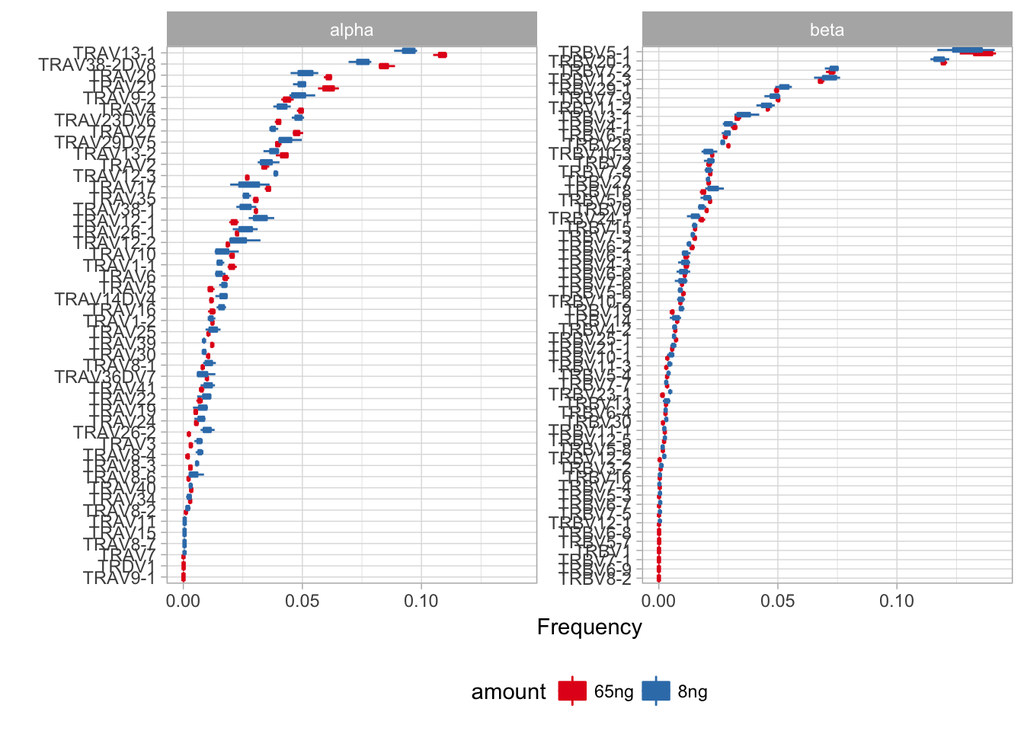

```r
ggplot(df.segm.v, aes(x=v, group=interaction(v,amount), y=freq, color=amount, fill=amount)) +
  geom_boxplot() +
  coord_flip() +
  facet_wrap(~chain, scale="free_y") +
  xlab("") + ylab("Frequency") +
  scale_color_brewer(palette = "Set1") +
  scale_fill_brewer(palette = "Set1") +
  theme_light() + theme(legend.position="bottom")
```

```r
a <- aov(freq ~ v + amount : v, df.segm.v)
summary(a)
```

[output not shown]

Joining segment usage

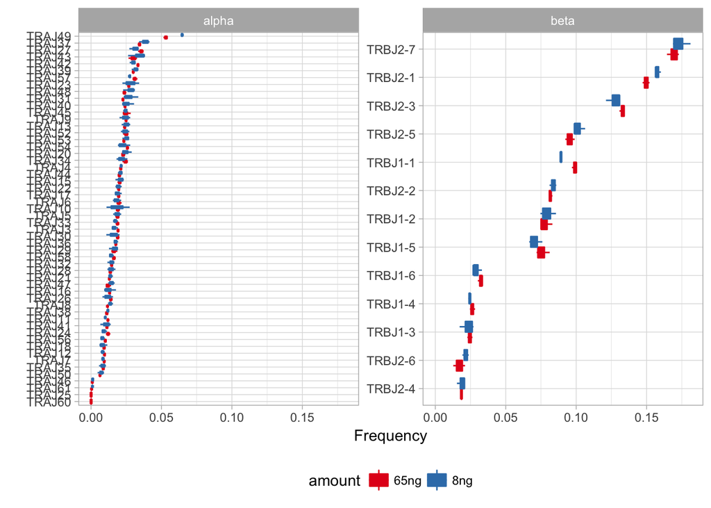

```r
ggplot(df.segm.j, aes(x=j, group=interaction(j,amount), y=freq, color=amount, fill=amount)) +
  geom_boxplot() +
  coord_flip() +
  facet_wrap(~chain, scale="free_y") +
  xlab("") + ylab("Frequency") +
  scale_color_brewer(palette = "Set1") +
  scale_fill_brewer(palette = "Set1") +
  theme_light() + theme(legend.position="bottom")
```

```r
a <- aov(freq ~ j + amount : j, df.segm.j)
summary(a)
```

```
##              Df Sum Sq Mean Sq F value   Pr(>F)
## j            66 0.4356 6.6e-03 925.840  < 2e-16 ***
## j:amount     65 0.0010 1.5e-05   2.087 2.61e-05 ***
## Residuals   260 0.0019 7.0e-06
## ---
## Signif. codes:  0 '***' 0.001 '**' 0.01 '*' 0.05 '.' 0.1 ' ' 1
```

> Note that there is some difference is segment usage related to the starting amount of RNA

V-J segment pairing

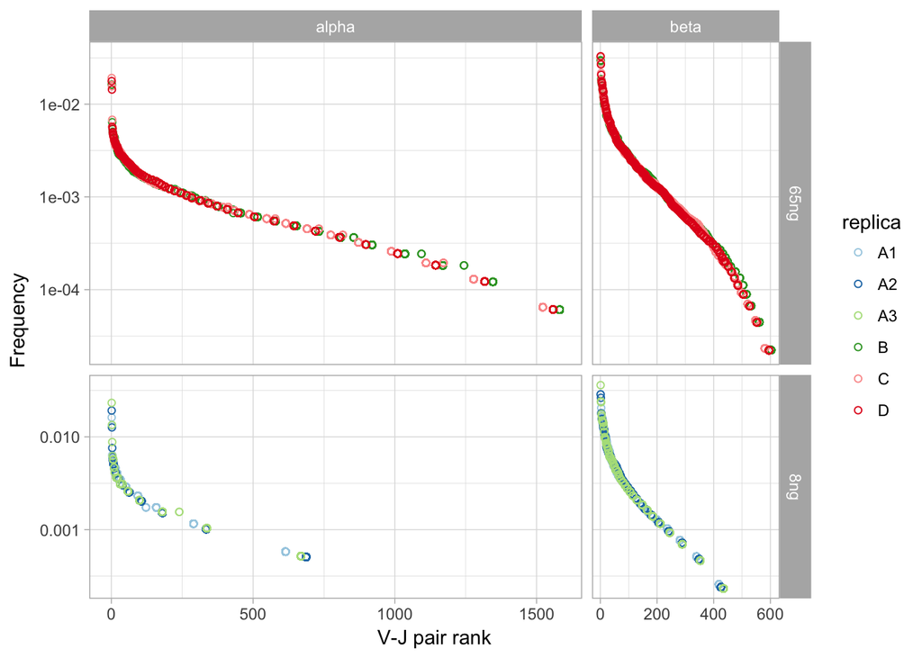

```r
ggplot(df.segm, aes(x=freq.rank, y=freq, color=replica)) +
  geom_point(shape=21) +
  xlab("V-J pair rank") +
  scale_y_log10("Frequency") +
  facet_grid(amount~chain, scale="free", space = "free") +
  scale_color_brewer(palette = "Paired") +
  theme_light()
```

### Spectratype

```r
df.sp = df %>%
  mutate(cdr3.len = nchar(cdr3nt)) %>%
  group_by(replica, chain, amount, cdr3.len) %>%
  summarize(freq = sum(freq), uniq=n())
```

CDR3 length distribution and out-of-frame sequences

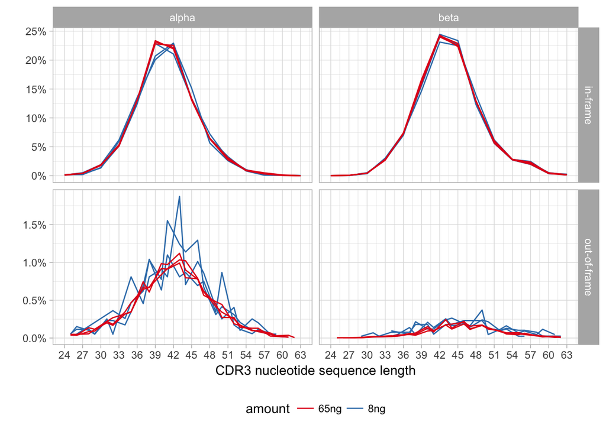

```r
df.sp$in.frame = ifelse(df.sp$cdr3.len %% 3 == 0, "in-frame", "out-of-frame")
ggplot(df.sp, aes(x=cdr3.len, y=freq, color=amount)) +
  geom_line(aes(group=replica)) +
  scale_x_continuous("CDR3 nucleotide sequence length", limits=c(24, 63), breaks = seq(21, 66, by=3)) +
  scale_y_continuous("", labels=percent) +
  facet_grid(in.frame~chain, scales="free") +
  scale_fill_brewer(palette = "Set1") +
  scale_color_brewer(palette = "Set1") +
  theme_light() + theme(legend.position="bottom")
```

## Clonotype abundance quantification

Clonotype frequency and rank

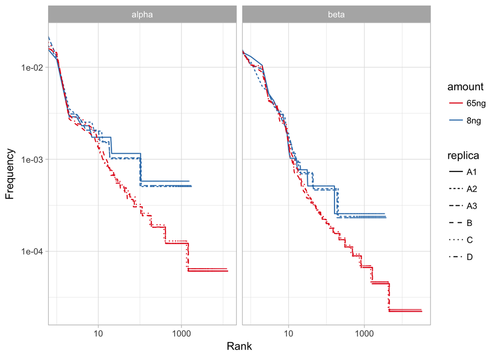

```r
ggplot(df, aes(x=clone.id, y=freq, linetype=replica, group=replica, color=amount)) +
  geom_line() +
  scale_y_log10("Frequency") + scale_x_log10("Rank") +
  facet_grid(~chain, scales="free") +
  scale_color_brewer(palette = "Set1") +
  theme_light()
```

```r
# Do some preprocessing

df.1 = df %>%
  select(cdr3nt, replica, amount, count, chain)

# fill missing clonotypes with 0
dummy = expand.grid(cdr3nt = unique(df.1$cdr3nt),
                    replica = unique(df.1$replica),
                    chain = unique(df.1$chain),
                    amount = unique(df.1$amount))

real_ccdr = interaction(df.1$chain, df.1$cdr3nt)
real_replamount = interaction(df.1$replica, df.1$amount)
dummy = subset(dummy, interaction(chain, cdr3nt) %in% real_ccdr)
dummy = subset(dummy, interaction(replica, amount) %in% real_replamount)
dummy$count = 0

df.1 = rbind(df.1, dummy) %>%
  group_by(cdr3nt, chain, replica, amount) %>%
  summarize(count = sum(count))

df.1$count.grand = sum(df.1$count)

df.1 = df.1 %>%
  group_by(cdr3nt) %>%
  mutate(count.total = sum(count)) %>%
  group_by(replica) %>%
  mutate(count.replica.total = sum(count))
```

Clonotype frequency in different replicas versus clonotype frequency in the pooled dataset

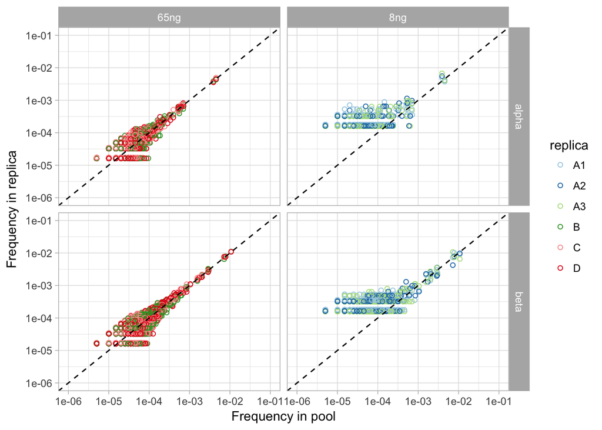

```r
ggplot(subset(df.1,count>0), aes(x=count.total/count.grand,
                                  y=count/count.replica.total)) +
  geom_point(aes(color=replica), shape=21) +
  geom_abline(slope = 1, intercept = 0, color="black", linetype="dashed") +
  facet_grid(chain~amount, space="free", scales="free") +
  scale_x_log10("Frequency in pool", limits=c(1e-6,1e-1), breaks=10^(-6:-1)) +
  scale_y_log10("Frequency in replica", limits=c(1e-6,1e-1), breaks=10^(-6:-1)) +
  scale_color_brewer(palette = "Paired") +
  theme_light()
```

### Clonotype cDNA count

Distribution of clonotype count in 8ng and 65 ng samples for clonotypes from different frequency tiers as computed based on the pooled dataset.

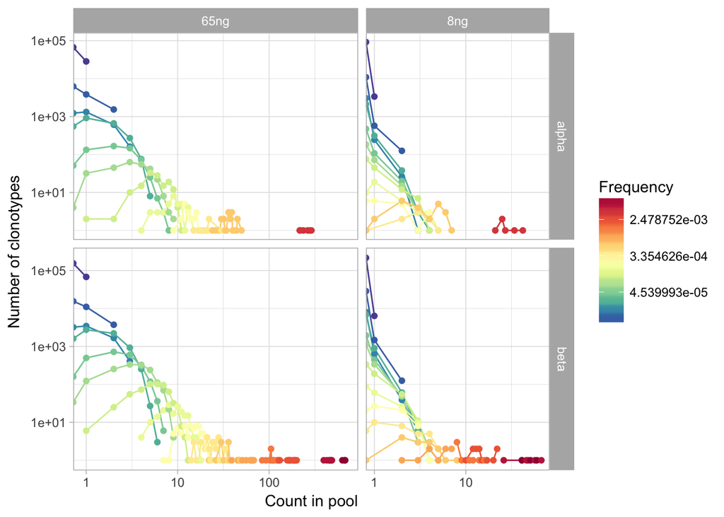

```r
df.2 = df.1 %>%
  mutate(log.freq = round(5*log10(count.total/count.grand))/5) %>%
  group_by(count, amount, chain, log.freq) %>%
  summarize(nn = n()) %>%
  group_by(amount, log.freq) %>%
  mutate(P = nn / sum(nn))

rf <- colorRampPalette(rev(brewer.pal(11, 'Spectral')))
r <- rf(40)

ggplot(subset(df.2), aes(x = count, y = nn, color=10^log.freq,
                         group=factor(log.freq))) +
  geom_line() +
  geom_point() +
  facet_grid(chain~amount, scales="free", space = "free") +
  scale_y_log10("Number of clonotypes") +
  scale_x_log10("Count in pool") +
  scale_color_gradientn("Frequency", colors=r, trans="log") +
  theme_light()
```

**Discrete case** Coefficient of variance versus clonotype abundance. Dashed and dotted lines show CV of Poisson and Beta Binomial distribution with $B(1/2,1/2)$ prior respectively. Note that while rare clonotypes are nicely fitted with a simple Poisson model, high-abundance clonotypes have relatively high coefficient of variance (plausible explanations: TCR expression, cell clumping).

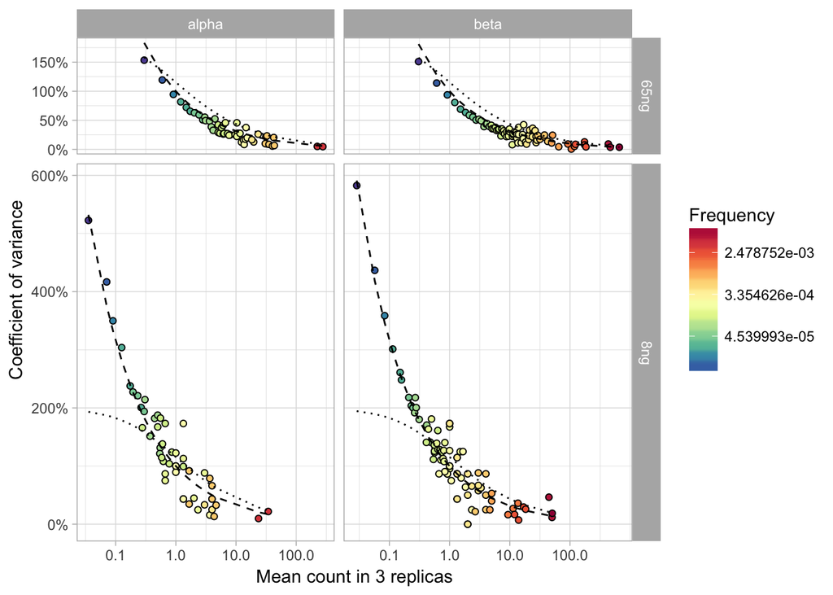

```r
df.3 = df.1 %>%
  group_by(amount, chain, count.total, count.grand) %>%
  summarize(count.mean = mean(count),
            count.sd = sd(count),
            mean.replica.size = mean(count.replica.total)) %>%
  group_by(count.mean, mean.replica.size) %>%
  mutate(a = count.mean + 1/2,
         b = mean.replica.size - count.mean + 1/2,
         bb.mean = mean.replica.size * a / (a + b),
         bb.sd = sqrt(mean.replica.size * a * b * (a + b + mean.replica.size) / (a + b) / (a + b) / (a + b + 1)))

ggplot(df.3) +
  geom_point(aes(x=count.mean, y = count.sd / count.mean,
                 fill=10^(round(5*log10(count.total/count.grand))/5)), color="black", shape=21) +
  geom_line(aes(x=count.mean, y = 1 / sqrt(count.mean)), color="black", linetype="dashed") +
  geom_line(aes(x=count.mean, y = bb.sd / bb.mean), color="black", linetype="dotted") +
  facet_grid(amount~chain, scales="free", space = "free") +
  scale_y_continuous("Coefficient of variance", labels = percent) +
  scale_x_log10("Mean count in 3 replicas", breaks = c(0.1, 1, 10, 100)) +
  scale_fill_gradientn("Frequency", colors=r, trans="log") +
  theme_light()
```

### High-abundance clonotypes

**Continuous case** Coefficient of variance for log-transformed frequencies

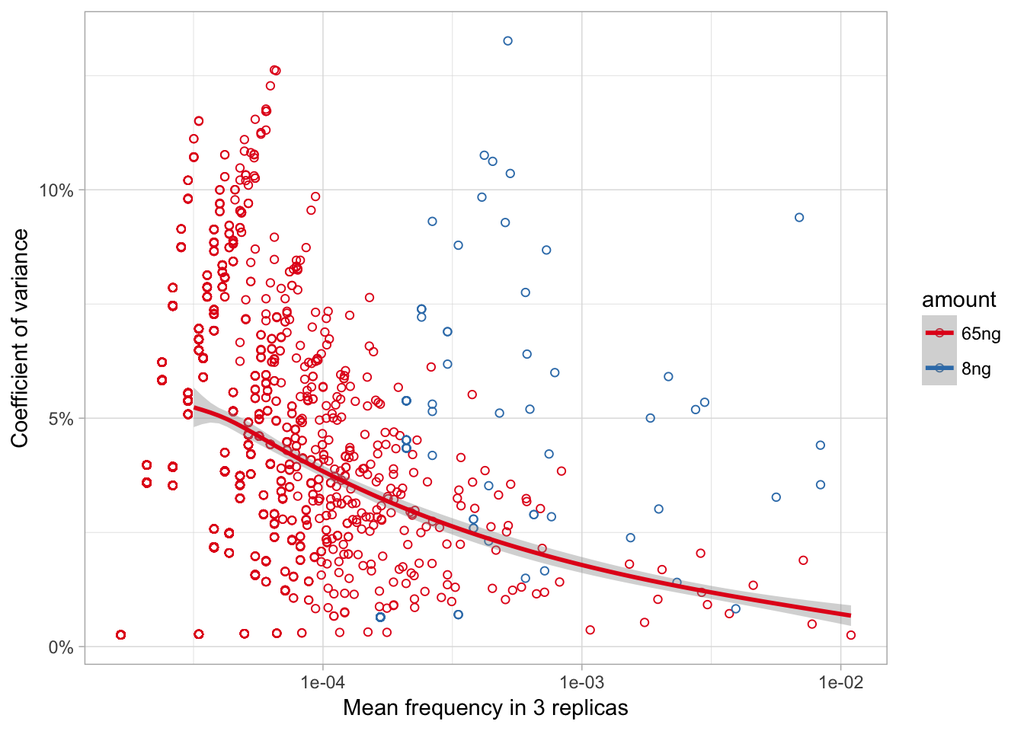

```r
df.5 = df.1 %>%
  group_by(cdr3nt, amount) %>%
  mutate(min.count = min(count)) %>%
  filter(min.count > 0)

df.5 = df.5 %>%
  group_by(cdr3nt, amount, replica) %>%
  mutate(freq = log10(count / count.replica.total)) %>%
  group_by(cdr3nt, amount) %>%
  summarize(freq.mean = mean(freq), freq.sd = sd(freq))

ggplot(df.5, aes(x=10^freq.mean, y=freq.sd/abs(freq.mean), color = amount)) +
  geom_point(shape=21) +
  geom_smooth(data=df.5 %>% filter(freq.mean > -4.5, amount == "65ng"),
                method="lm", aes(weight=10^freq.mean), formula = y~ns(x,3)) +
  scale_x_log10("Mean frequency in 3 replicas") +
  scale_y_continuous("Coefficient of variance", labels=percent) +
  scale_color_brewer(palette = "Set1") +
  theme_light()
```

```r
# Some ANOVA analysis

a <- aov(freq.sd / abs(freq.mean) ~ freq.mean + amount, df.5)
summary(a)
```

```
##               Df Sum Sq Mean Sq F value   Pr(>F)
## freq.mean      1 0.0782 0.07819   127.5  < 2e-16 ***
## amount         1 0.0231 0.02311    37.7 9.09e-10 ***
## Residuals   3935 2.4126 0.00061
## ---
## Signif. codes:  0 '***' 0.001 '**' 0.01 '*' 0.05 '.' 0.1 ' ' 1
```

> Two way ANOVA test for coefficient of variance vs. mean frequency and input amount. All frequencies are log-transofrmed.

```r
# Get some high-abundance clonotypes

top10_clones = df.1 %>%
  group_by(cdr3nt) %>%
  summarize(x = mean(count.total)) %>%
  mutate(rank = rank(-x)) %>%
  arrange(rank) %>%
  filter(rank <= 10)

df.4 = subset(df.1, cdr3nt %in% top10_clones$cdr3nt)
```

Plot frequency variance for top $10$ clonotypes

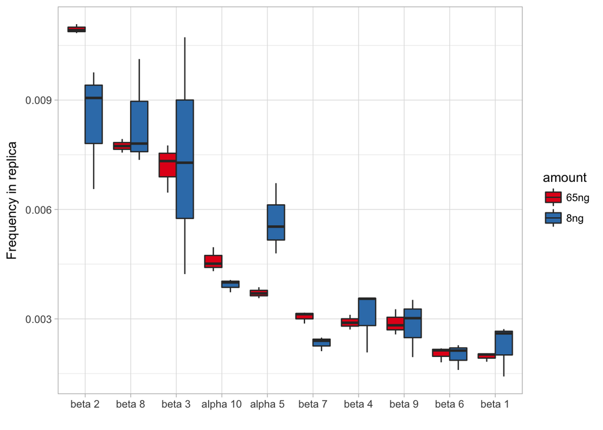

```r
df.4$clone.id = paste(df.4$chain, as.integer(as.factor(df.4$cdr3nt)))
df.4$clone.id = factor(df.4$clone.id, df.4$clone.id[order(-df.4$count.total)])

ggplot(df.4, aes(x=clone.id, group=interaction(clone.id,amount),
                 fill=amount, y=count/count.replica.total)) +
  geom_boxplot() + xlab("") + ylab("Frequency in replica") +
  scale_fill_brewer(palette = "Set1") +
  theme_light()
```